# Animated Map of Global Coverage

Michael Harper

Last updated: 30 March, 2020

Code to produce the animated global map:

```r
# Laod packages
library(here)
library(readr)
library(tidyverse)
library(sf)
library(maps)
library(gganimate)
library(patchwork)
library(ggthemr)
library(grid)
library(magick)

# devtools::install_github('cttobin/ggthemr')
ggthemr("light")
```

# Data Loading and Preparation

As in my [previous analysis](https://mikeyharper.uk/Covid-19-march-17/), I’ll be using the John hopkins dataset.As a reminder, the data can be accessed through the GitHub [repository here](https://github.com/CSSEGISandData/Covid-19), and they also offer a great dashboard for visualising the data [here](https://coronavirus.jhu.edu/map.html).

# Producing the plots

There are two components to the plot:

1. The map itself
2. A timeline bar which shows the progress along the bottom

Using the **gganimate** package, you need to produce these two separately then merge the results. First we will prep the data for the plot and then produce the base ggplot which we will animate afterwards. Note, there are a few workarounds in the following cocde. First I am finding the earlier date for each region that there was a a reported case:

```r
# Extracts the first cases
df_firstcase <-
  df_all_spatial %>%
  filter(type == "cases") %>%
  group_by(region) %>%
  filter(value > 0) %>%
  filter(date == min(date, na.rm = T)) %>%
  filter(!is.na(continent)) %>%
  ungroup()
```

Next we convert the spatial data from a spatial feature into a slightly old-fashioned format for doing spatial data in ggplot using the `fortify` function. I would typically use the `geom_sf` option but this is not yet fully supported by gganimate.

```r
# Convert geometry to format to allow to work with gganimate
# gganiamte currently doesn't support sf
df_firstcase_sp <-
  df_firstcase %>%
  as("Spatial")

d <- merge(fortify(df_firstcase_sp), as.data.frame(df_firstcase_sp), by.x="id", by.y=0)
```

I want the graph to display a frame for every date, even if there is no change in the countries which are reporting infection. I therefore created a placeholder dataframe which had the same format as the spatial data above, but only gave a date value. This will trick **gganimate** into thinking there is data to display for every slide.

```r
# Create a placeholder dataframe which has every date in a sequence
# This is used to force gganimate to display every single day even if there is no change
# in the data
allDays <-seq(from = min(d$date), to = max(d$date), by = lubridate::ddays(1))

allDaysDf <- data.frame("id" = NA,
                        "long" = NA,
                        "lat" = NA,
                        "order" = NA,
                        "hole" = NA,
                        "piece"  = NA,
                        "group" = "extra",
                        "region" = NA,
                        "continent" = NA,
                        "date" = allDays,
                        "value" = NA,
                        "type" = NA,
                        "pop" = NA,
                        "casespermillion" = NA)

f <- bind_rows(d, allDaysDf)
```

Finally I will build the ggplot. First I specify just the raw components, with nothing different for the animation yet:

```r
# Make the plot
plot_map <-
  ggplot(d) +
  geom_sf(data = world_map, fill = "grey90", colour = "#dadada") +
  geom_polygon(aes(x = long, y = lat, group = group), fill = "#3a6589") +
  labs(title = "Countries with reported Covid-19 Cases") +
  theme(plot.caption = element_text(size = rel(0.5)),
        plot.background = element_rect(fill = NA, colour = NA),
        panel.background = element_blank(),
        axis.text = element_blank(),
        axis.ticks = element_blank(),
        axis.line = element_blank(),
        axis.title = element_blank(),
        panel.grid = element_blank(),
        legend.background = element_blank(),
        title = element_text(colour = '#706f6f', size = rel(2), hjust = 0.5),
        plot.title = element_text(colour = '#706f6f', size = rel(1.5), hjust = 0.5),
        legend.position = "none")
```

If you are new to gganimate, it offers a fairly user-friendly way of animating plots. We can take our base ggplot object above and add `transition_states` which will progressively go through the dates and show data for each date. I had initially wanted to use `transition_reveal`, but I couldn’t find a way to make these smoothly animate data as they were added to the graph as it doesn’t seem to accept any of the transition aes arguments. As a slight work around to make `transition_states` work, I used the `shadow_mark` to make the data remain on the map:

```r
nframesAnim <- length(allDays) * 2
durationAnim <- 15

plot_anim <- plot_map +
  transition_states(date, wrap = F) +
  enter_recolor(fill = "#f0f5f9") +
  shadow_mark(past = T, alpha = 1, fill = "#3a6589")

# Render the map
gif1 <- animate(plot = plot_anim,
                height = 768,
                width =1800,
                nframes = nframesAnim,
                duration = durationAnim,
                end_pause = 10)
```

We will also produce the timeline below the plot:

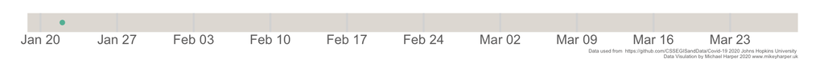

```r
# Select first and last date to interpolate between
# For some reason this is smoother than letting gganimate do every single point
g <- allDaysDf[c(1,nrow(allDaysDf)),]

plot_timeline <-
  ggplot(g, aes(x = date, y = 1)) +
  geom_point(aes(group = 1L), size = 5) +
  scale_x_datetime(date_labels = "%b %d", date_breaks = "1 week") +
  labs(caption = "Data used from  https://github.com/CSSEGISandData/Covid-19 2020 Johns Hopkins University \nData Visulation by Michael Harper 2020 www.mikeyharper.uk") +
  theme(aspect.ratio = 0.025,
        legend.position = "none",
        axis.text.y = element_blank(),
        axis.text.x = element_text(size = rel(3)),
        axis.title = element_blank(),
        axis.line.y = element_blank(),
        axis.ticks = element_blank(),
        axis.line.x = element_blank(),
        panel.grid = element_blank(),
        panel.grid.major.x = element_line(size = 2, linetype = "solid"),
        plot.background = element_rect(fill = NA, colour = NA),
        plot.margin = margin(1, 2, 0, 2, "cm"),
        panel.background = element_rect(fill = '#e3dfda', colour = NA))

gif2 <- animate(
  plot_timeline +
    transition_states(date,
                      transition_length = 1,
                      state_length = 0,
                      wrap = F),
  width =1800, height = 130, nframes = nframesAnim, duration = durationAnim, end_pause = 10, rewind = F
)
gif2
```

**gganimate** does not natively support plotting multiple plots together, however it is very easy to achieve this using the **magick** package. A demo is given in the [wiki here](https://github.com/thomasp85/gganimate/wiki/Animation-Composition).

```r
a_mgif <- image_read(gif1)
b_mgif <- image_read(gif2)

new_gif <- image_append(c(a_mgif[1], b_mgif[1]), stack = T)
for(i in 2:nframesAnim){
  combined <- image_append(c(a_mgif[i], b_mgif[i]), stack = T)
  new_gif <- c(new_gif, combined)
}
```

We can visualise the final gif below!

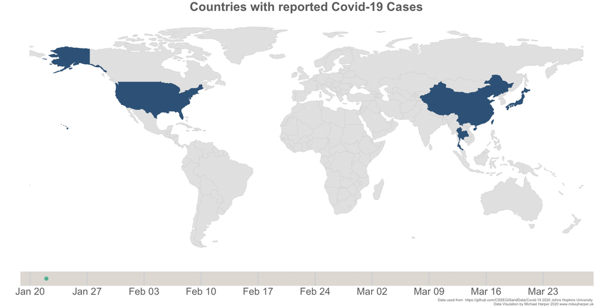